# Encuesta sobre hábitos de estudio

Jean Paul Yepes, Alejandro Santamaria Espinosa, Evelyn Dayanna Bermudez, Elver Noe Tunubala, Paula Andrea Cifuentes

16 de septiembre de 2020

# Limpieza de la base de datos

## Limpieza de las carreras

Los nombres de las carreras en los datos no estan de una manera unificada, como se puede evidenciar en la tabla algunos escriben la misma carrera de modo distinto, por lo que esta columna se limpiará unificando los nombres de las carreras de un solo modo.

| Carreras |
| --- |
| Estadística |
| Estadistica |
| estadística |
| Estadsitica |
| estadistica |
| ESTADISTICA |
| ESTADÍSTICA |

En la tabla siguiente podemos ver el resultado de unificar el resultado de corregir los nombres de las carreras, ahora todas las carreras tienen un nombre único y no hay ambiguedad sobre las carreras que estan presentes.

| Carreras |
| --- |
| Ingenieria de control |
| Ingenieria de sistemas |
| Estadistica |
| Ingenieria industrial |
| Ingenieria administrativa |
| Ingenieria fisica |
| Matemáticas |
| Ingeniería Biológica |

## Limpieza de la variable computador propio

En la tabla tenemos los posibles valores que podemos obtener con los computadores propios, como se puede evidenciar la variable toma cuatro valores, pero cuando las personas tienen un computador casi siempre suelen ser de ellos, por lo que solo vamos a dejar que las variables tomen el valor de si o no.

|  | Cantidad |
| --- | --- |
| No | 91 |
| Si, pero prestado | 3 |
| Si, pero alquilado. | 1 |
| Si, propio. | 37 |

|  | Cantidad |
| --- | --- |
| No | 91 |
| Si | 41 |

## Limpieza datos smartphone

Del mismo modo en la siguiente tabla podemos ver que las otras categorías del si no aportan mucha información por lo que es mas conveniente unificar esta categoría en una sola y asumir que el celular que se usa es de ellos.

|  | Cantidad |
| --- | --- |
| No | 1 |
| Si, alquilado. | 1 |
| Si, prestado. | 2 |
| Si, propio. | 127 |
| NA’s | 1 |

En la siguiente tabla podemos ver los resultados.

|  | Cantidad |
| --- | --- |
| No | 1 |
| Si | 130 |
| NA’s | 1 |

## Limpieza de datos portatil

Para la limpieza de datos del portatil se separo esta variable en dos columnas. La primera si tiene portatil, la segunda para saber de quien es el portatil.

| portatil |
| --- |
| Si, propio. |
| Si, propio. |
| No |
| Si, pero prestado. |
| Si, propio. |
| Si, propio. |

| portatil | ¿De quien es el portatil? |
| --- | --- |
| Si | propio. |
| Si | propio. |
| No | NA |
| Si | pero prestado. |
| Si | propio. |
| Si | propio. |

## Limpieza de datos internet

| internet |
| --- |
| Si. familiar, |
| Si. familiar, |
| Si. familiar, |
| Si. familiar, |
| Si, propio. |
| Si, propio. |

| internet | ¿De quien es el internet? |
| --- | --- |
| Si | familiar |
| Si | familiar |
| Si | familiar |
| Si | familiar |
| Si | propio |
| Si | propio |

## Correccion de las fechas

Existen algunas fechas que no estan formateadas adecuadamente para el analisis por lo que se tienen que remplazar estas fechas de un modo adecuado.

|  | consecutivo | fecha_nac | fecha_nac_correcta |
| --- | --- | --- | --- |
| 2 | 2 | 05/09/99 | 05/09/1999 |
| 12 | 12 | 08/10/96 | 08/10/1996 |
| 27 | 27 | 06/03/20 | 06/03/2020 |
| 32 | 32 | /-/-/1994 | 01/07/1994 |
| 44 | 44 | 01/0!/2000 | 01/01/2000 |
| 45 | 45 | 07102003 | 07/10/2003 |
| 46 | 46 | 170992 | 17/09/1992 |
| 49 | 49 | 12/08/20 | 12/08/2020 |
| 57 | 57 | 12/05/98 | 12/05/1998 |
| 67 | 67 | 21/06//83 | 21/06/1983 |
| 74 | 74 | 12/08/20 | 12/08/2020 |
| 82 | 82 | 28/09/56 | 28/09/1956 |
| 90 | 90 | 09/06/99 | 09/06/1999 |
| 96 | 96 | 10/09/02 | 10/09/2002 |
| 114 | 114 | 20\06\1994 | 20/06/1994 |

# Análisis variables

## Análisis de habitos de estudio

### Análisis exploratorio de la variable habitos de estudio

Los habitos de estudio mas comunes en los estudiantes son: tomar pasuas cada cierto tiempo, resolver ejercicios sin ver las respuestas y tomar notas de los ejercicios en clase. Con respecto a como los estudiante estudian parece que ellos prefieren estudiar con amigos algunas veces. Aunque los habitos mas efectivos son establecer horarios de estudio y resolver los ejercicios anticipadamente.

### Análisis habitos contradictorios

Se observa que los estudiantes que resuelven los ejercicios sin ver las respuestas les tiende a ir mejor que las personas que memorizan ejercicios para el examen, parece que un habito que mejoraría las notas de los estudiantes sería enfrentarse a ejercicios.

Similarmente los que estudian con amigos tienen un mejor PAPA que los que estudian solos, aunque todavía no es concluyente porque la cantidad de personas que respondieron que estudian con amigos es muy poca en relación a los que estudian solos.

Otra comparación que podemos realizar a partir de los datos son las personas que estudian el día antes del examen, los que trasnochan el dían anterior y los que fijan un horario para estudiar, hay una gran diferencia a favor para los que fijan un horario para estudiar e inclusive los que trasnochan el día antes del examen el top 75% apenas llegan a la mediana de los que fijan un horario y el resultado es peor para los que estudian el dia antes.

### Tabla habitos de estudio

Tabla 10

|  | Cantidad |
| --- | --- |
| Toma pausas cada cierto tiempo de estudio continuo. | 96 |
| Resuelve usted mismo los ejercicios sin ver las respuestas anticipadamente. | 90 |
| Tomas notas transcribiendo los ejercicios en clase. | 88 |
| Algunas veces estudia solo otras veces con amigos. | 76 |
| Usa los solucionarios para ver los ejercicios resueltos. | 75 |
| Selecciona un lugar fijo de estudio. | 69 |
| Prefiere pocos ejercicios bien entendios a dar un vistazo a muchos ejercicios resueltos. | 68 |
| Solo le pregunta a los amigos los ejercicios que no pudo resolver. | 62 |
| Estudia solo. | 59 |
| Trasnocha estudiando para un examen. | 52 |
| Lee varias veces un mismo capítulo del libro texto. | 50 |
| Escucha su música favorita mientras estudia. | 49 |
| Madruga a estudiar. | 45 |
| Hace un horario de estudio y se ajusta estrictamente a ese horario. | 44 |
| Estudia todo el tema el día anterior del examen. | 36 |
| Estudia varios temas distintos en una misma sesión de estudio. | 36 |
| Prefiere dar un vistazo a ejercicios resueltos de todos los posibles ejercicios. | 35 |
| Los ejercicios los hace junto con los amigos de estudio. | 27 |
| Memoriza ejercicios. | 19 |
| Estudia con amigos. | 15 |
| Estudia solamente las soluciones de los libros o de los compañeros. | 3 |

### Tabla mediana habitos de estudio

| Habitos | Medianas |
| --- | --- |
| Tomas notas transcribiendo los ejercicios en clase. | 3.65 |
| Escucha su música favorita mientras estudia. | 3.60 |
| Selecciona un lugar fijo de estudio. | 3.60 |
| Estudia varios temas distintos en una misma sesión de estudio. | 3.70 |
| Algunas veces estudia solo otras veces con amigos. | 3.70 |
| Toma pausas cada cierto tiempo de estudio continuo. | 3.70 |
| Usa los solucionarios para ver los ejercicios resueltos. | 3.60 |
| Resuelve usted mismo los ejercicios sin ver las respuestas anticipadamente. | 3.80 |
| Prefiere dar un vistazo a ejercicios resueltos de todos los posibles ejercicios. | 3.60 |
| Hace un horario de estudio y se ajusta estrictamente a ese horario. | 3.80 |
| Solo le pregunta a los amigos los ejercicios que no pudo resolver. | 3.70 |
| Estudia todo el tema el día anterior del examen. | 3.70 |
| Prefiere pocos ejercicios bien entendios a dar un vistazo a muchos ejercicios resueltos. | 3.70 |
| Estudia solo. | 3.70 |
| Trasnocha estudiando para un examen. | 3.65 |
| Los ejercicios los hace junto con los amigos de estudio. | 3.60 |
| Madruga a estudiar. | 3.70 |
| Memoriza ejercicios. | 3.60 |
| Lee varias veces un mismo capítulo del libro texto. | 3.70 |
| Estudia con amigos. | 3.80 |
| Estudia solamente las soluciones de los libros o de los compañeros. | 3.30 |

### Habitos de estudio vs PAPA

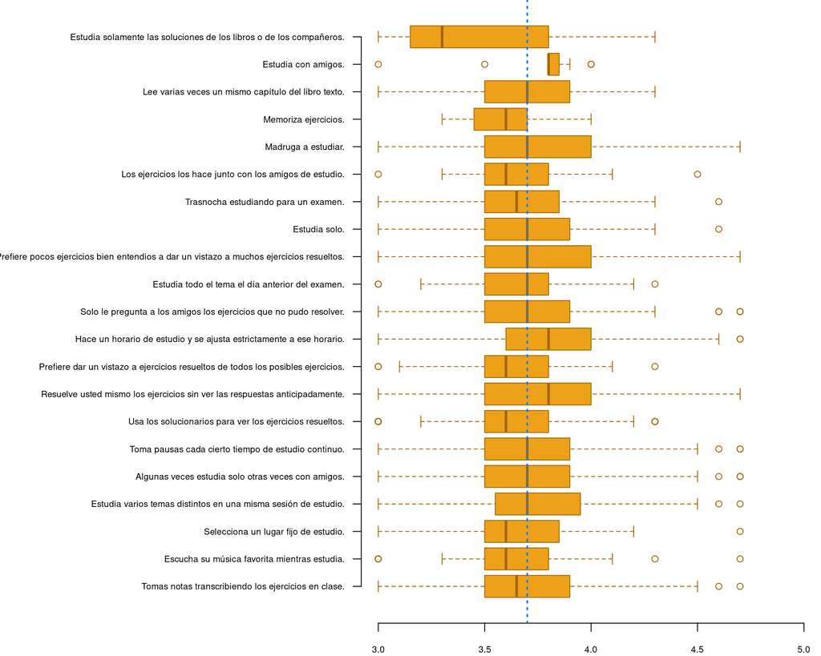

## Análisis de género

### Análisis exploratorio de la variable género

```
##    Femenino Masculino
## tg 35.00000  97.00000
## pg 26.51515  73.48485
```

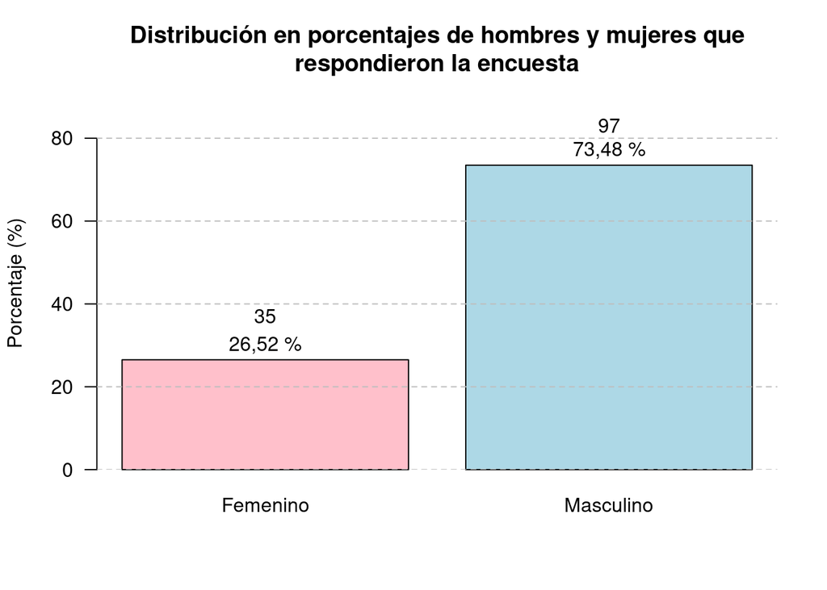

La gráfica anterior y las tablas nos muestran que hay casi el triple de hombres que de mujeres en el curso, lo cuál deberemos tener en cuenta para analizar las siguientes variables y tratar de entender que diferencias hay entre cada géneto.

### Relación del género con el PAPA

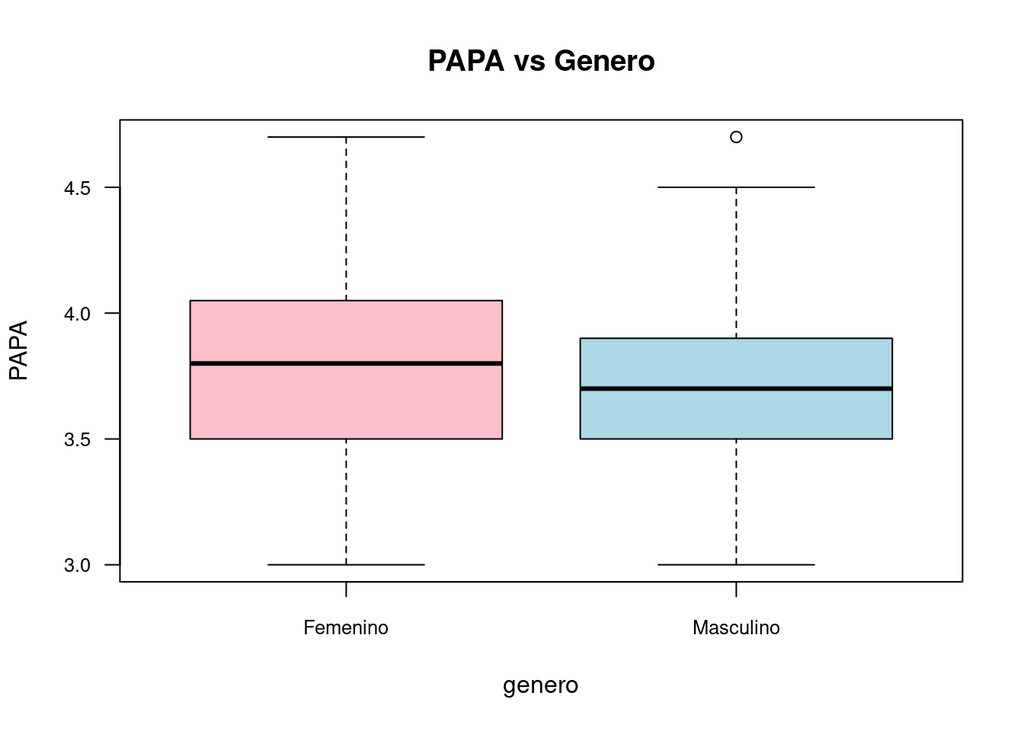

En el diagrama de caja y bigotes anterior podemos notar que las mujeres y los hombres comparten un PAPA muy similar en el percentil 50%, incluso vemos que tienen una media no muy diferente. Podemos notar una diferencia en que en el cuartil cuatro los hombres alcanzan un máximo de nota de alrededor de 4.5, teniendo un punto crítico con un hombre que tiene un PAPA en 4.7, y las mujeres de un 4,7 aproximadamente, sin ningún punto crítico.

### Análisis exploratorio para la variable fecha de nacimiento

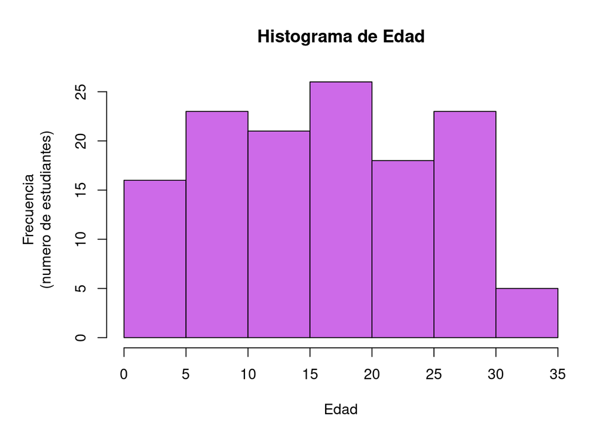

Como podemos observar estos datos contienen bastantes errores ya que vemos que incluso hay personas de 0 a 5 años o de 5 a 10 años, lo cuál es bastante improbable que sea cierto y tendríamos que revisar bien los datos. Algunos de ellos fueron corregidos porque el único problema que había era que estaban en un formato diferente a DD/MM/AAAA. Sin embargo los demás datos no daban suficiente claridad y seguramente están erróneos debido a la mala interpretación a la pregunta. También observamos que la edad más común es de 15 a 20 años y que aún las edades de 30 y 35 años tienen una menor frecuencia que los que “tienen” de 0 a 5 años. También vemos una frecuencia similar en las edades entre 5 y 10 años y 25 y 30 años. En conclusión, tenemos unos datos bastante errados.

### Relación de edad y PAPA

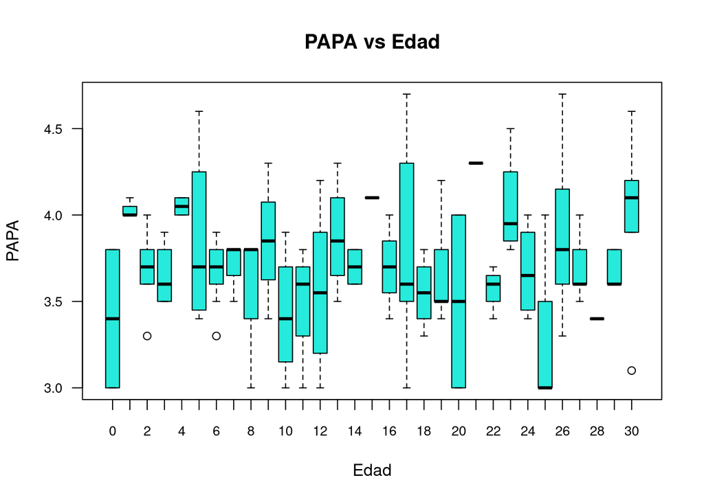

## Análisis de la carrera

### Analisis exploratorio para la variable carrera

```
##      Estadistica Ingenieria administrativa Ingeniería Biológica
## tcar     70.0000                  3.000000            1.0000000
## pcar     53.0303                  2.272727            0.7575758
##      Ingenieria de control Ingenieria de sistemas Ingenieria fisica
## tcar             1.0000000               50.00000          3.000000
## pcar             0.7575758               37.87879          2.272727
##      Ingenieria industrial Matemáticas
## tcar              2.000000    2.000000
## pcar              1.515152    1.515152
```

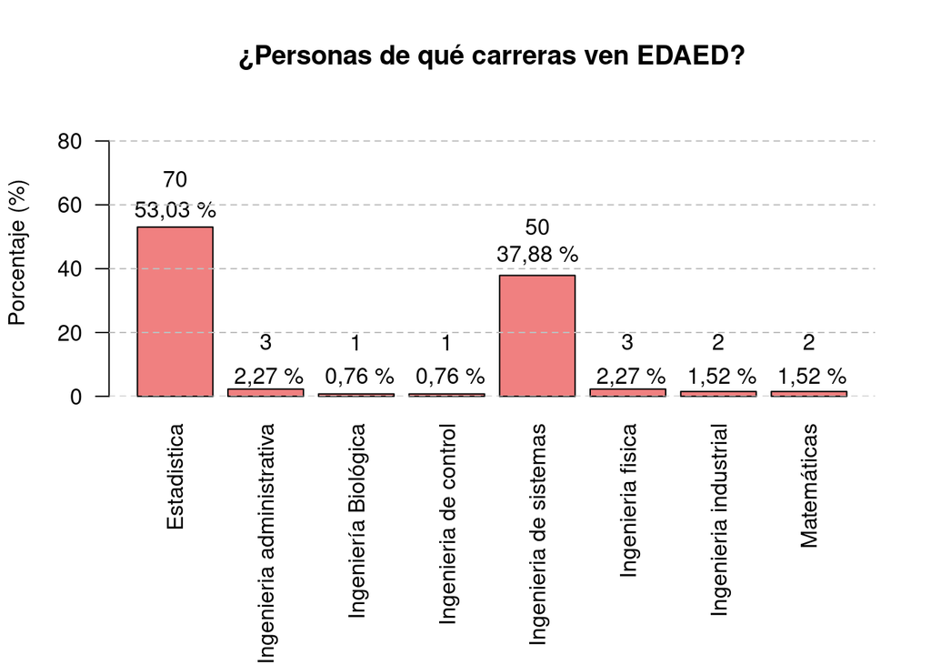

En la anterior gráfica de barras podemos notar que la carrera que más sobresale es Estadística, algo que se esperaba ya que esta materia es parte del curriculum de esta carrera. En segundo lugar vemos a Ing. de Sistemas con un 37,88% de los participantes en la encuesta, y se puede ver que las demás carreras son muy pocas y tienen un muy bajo porcentaje de personas.

### Relacionando carreras y el PAPA

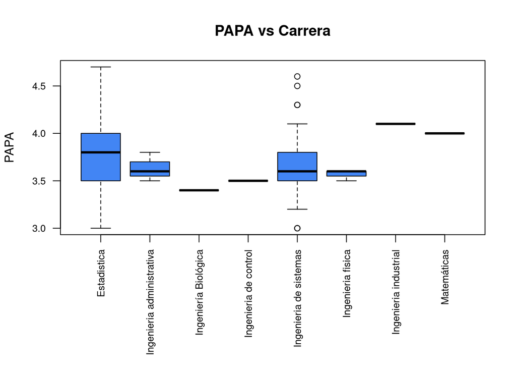

Como podemos ver en el diagrama de caja y bigotes las carreras que tienen muy pocas personas solo se muestran como una raya, esto es porque la caja es tan pequeña que no se ve sino su mediana. Podemos ver también 4 puntos atípicos en Ing. de Sistemas, en Estadística no encontramos puntos atípicos pero vemos que su diagrama se extiende desde la nota más pequeña hasta la más grande, incluso superando al punto atípico más alto en Ing de Sistemas.

## Análisis del PAPA

### Análisis exploratorio de la variable PAPA

```
##              3       3.1       3.2      3.3      3.4      3.5      3.6      3.7
## tpapa 9.000000 1.0000000 1.0000000 5.000000 8.000000 17.00000 17.00000 7.000000
## ppapa 7.317073 0.8130081 0.8130081 4.065041 6.504065 13.82114 13.82114 5.691057
##            3.8      3.85      3.9         4      4.1      4.2      4.3
## tpapa 20.00000 1.0000000 8.000000 12.000000 4.000000 3.000000 5.000000
## ppapa 16.26016 0.8130081 6.504065  9.756098 3.252033 2.439024 4.065041
##             4.5      4.6      4.7
## tpapa 1.0000000 2.000000 2.000000
## ppapa 0.8130081 1.626016 1.626016
```

```
##    Min. 1st Qu.  Median    Mean 3rd Qu.    Max.    NA's
##   3.000   3.500   3.700   3.709   3.900   4.700       9
```

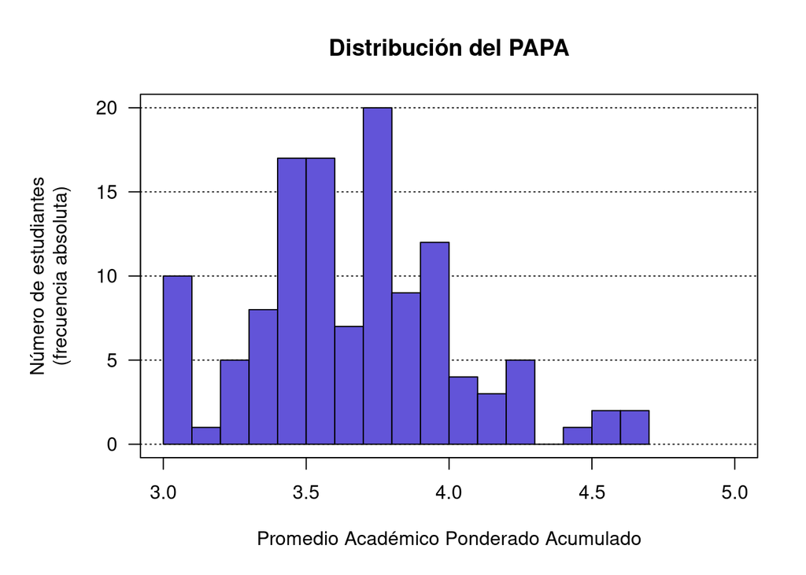

En el histograma anterior podemos notar que la mayoría de personas tienen un promedio entre 3,7 y 3,8. También podemos notar que hay la misma cantidad de personas con notas entre3,4 y 3,5 y 3,5 y 3,6. Tambien vemos que no hay nadie que tenga nota de entre 4,3 y 4,4 y que solo hay una persona con nota entre 3,1 y 3,2 y sucede lo mismo entre 4,4 y 4,5.

### Diagrama de caja y bigotes para PAPA

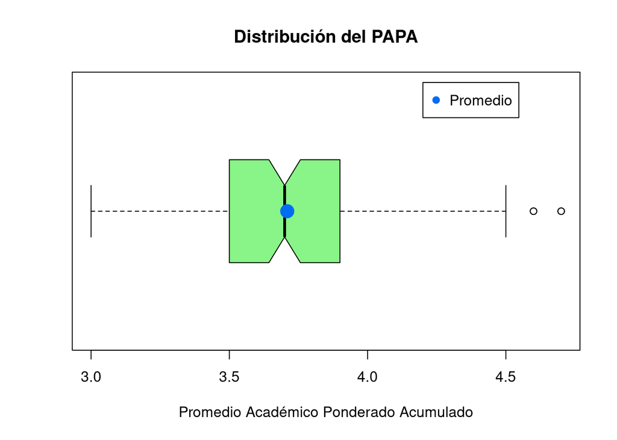

Podemos observar que la mediana y el promedio están en una posición muy similar. También vemos que hay solo dos puntos atípicos, con nota arriba de 4,5 lo cual no es tan común o son excepciones.

## Análisis de la variable smartphone

### Variable exploratorio de la variable smarthphone

### Tabla variable smartphone

```
##
##  Si  No
## 130   1
```

En (%)

```
##
##         Si         No
## 99.2366412  0.7633588
```

### Grafica smartphone

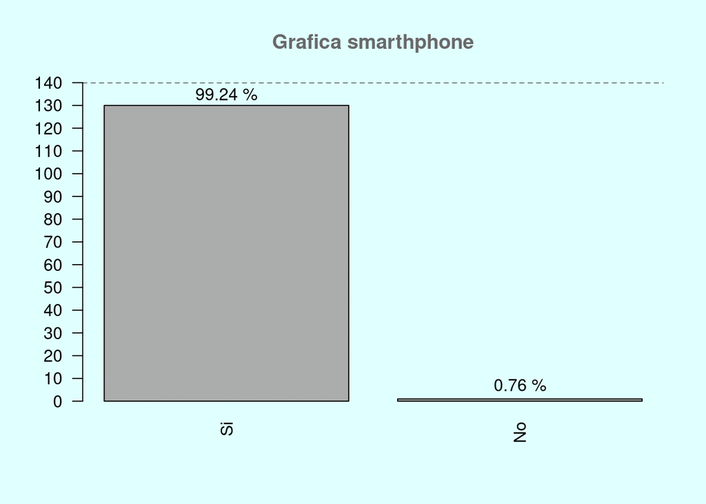

```
##    Min. 1st Qu.  Median    Mean 3rd Qu.    Max.    NA's
##   3.000   3.500   3.700   3.709   3.900   4.700       9
```

### Gráfica de smartphone vs PAPA

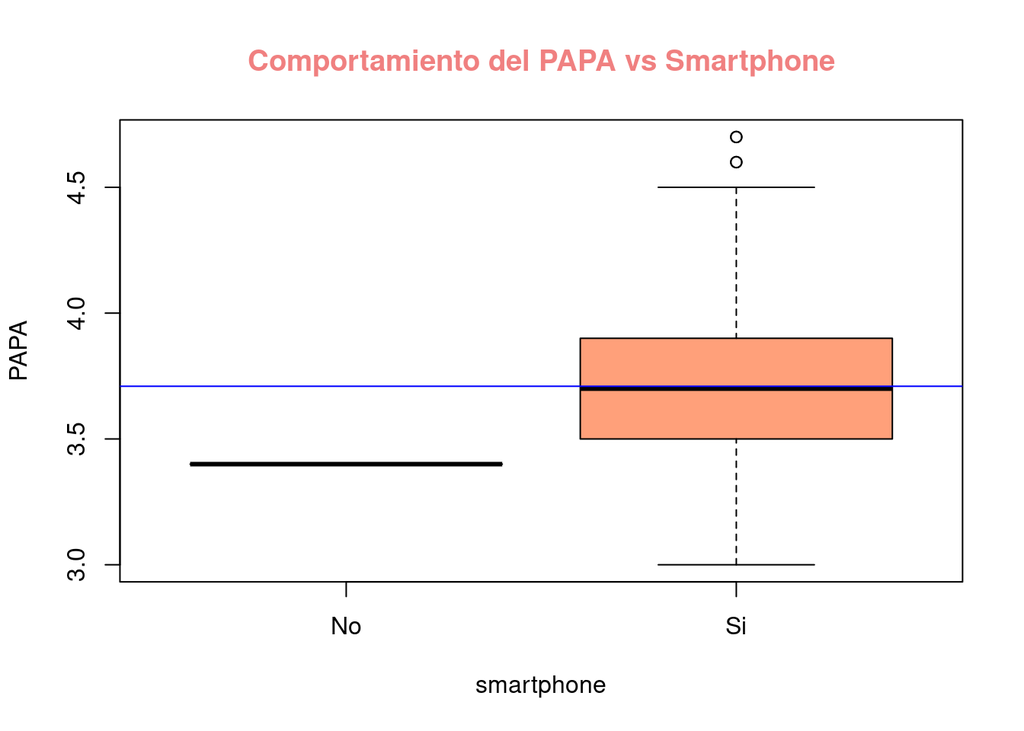

## Análisis origen covid 19

### Análisis exploratorio de la variable origen covid 19

Tabla 3

[output not shown]

TABLA MODIFICADA

[output not shown]

### Tabla origen covid 19

```
##
##                                  Animal                             Laboratorio
##                                      65                                      33
##                     Animal\nLaboratorio                           conspiracion
##                                       9                                       4
##              conspiracion \nLaboratorio                             No es real
##                                       2                                       2
##      conspiracion \nAnimal\nLaboratorio conspiracion \nNo es real \nLaboratorio
##                                       1                                       1
```

En (%)

```
##
##                                  Animal                             Laboratorio
##                              55.5555556                              28.2051282
##                     Animal\nLaboratorio                           conspiracion
##                               7.6923077                               3.4188034
##              conspiracion \nLaboratorio                             No es real
##                               1.7094017                               1.7094017
##      conspiracion \nAnimal\nLaboratorio conspiracion \nNo es real \nLaboratorio
##                               0.8547009                               0.8547009
```

### Grafica origen covid 19

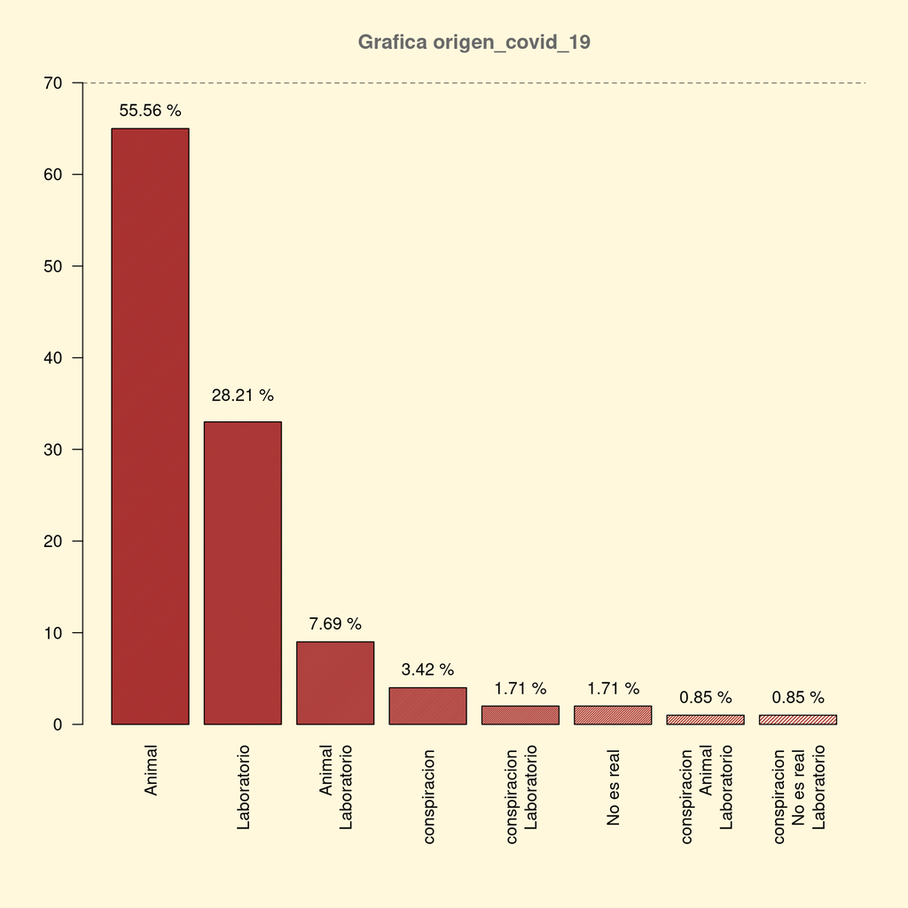

```
##    Min. 1st Qu.  Median    Mean 3rd Qu.    Max.    NA's
##   3.000   3.500   3.700   3.709   3.900   4.700       9
```

```
##    Length     Class      Mode
##       132 character character
```

### PAPA vs origen covid 19

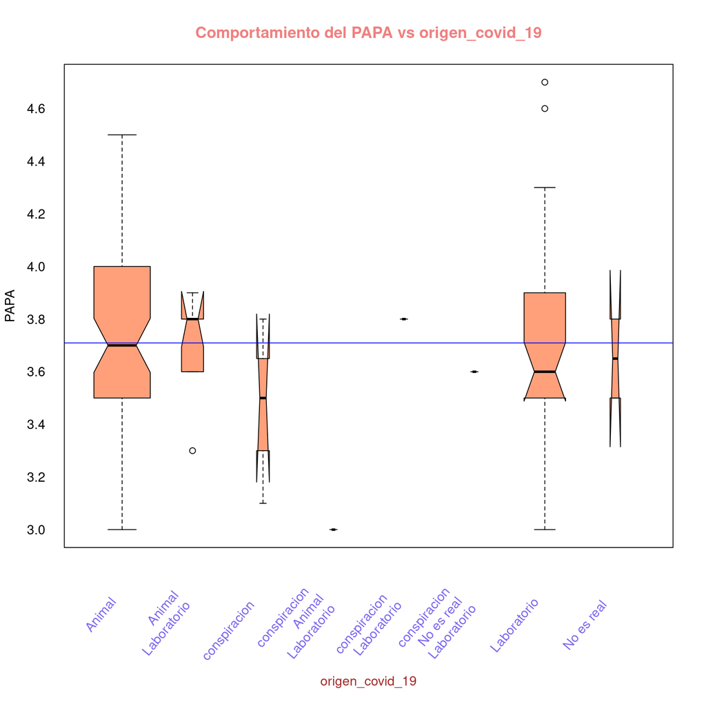

## Análisis de las estadísticas de gobierno

### Analisis exploratorio de la variable cree en las estadísticas de gobierno

TABLA.

```
##
## No Si
## 88 30
```

En (%)

```
##
##       No       Si
## 74.57627 25.42373
```

### Grafica estadisticas de gobierno

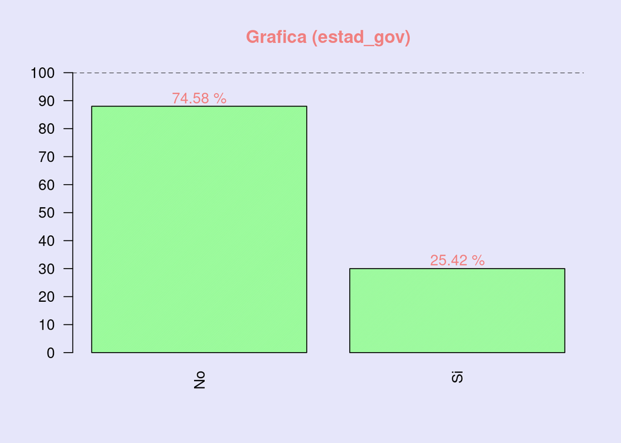

```
##    Min. 1st Qu.  Median    Mean 3rd Qu.    Max.    NA's
##   3.000   3.500   3.700   3.709   3.900   4.700       9
```

```
##    Length     Class      Mode
##       132 character character
```

### PAPA vs estadisticas de gobierno

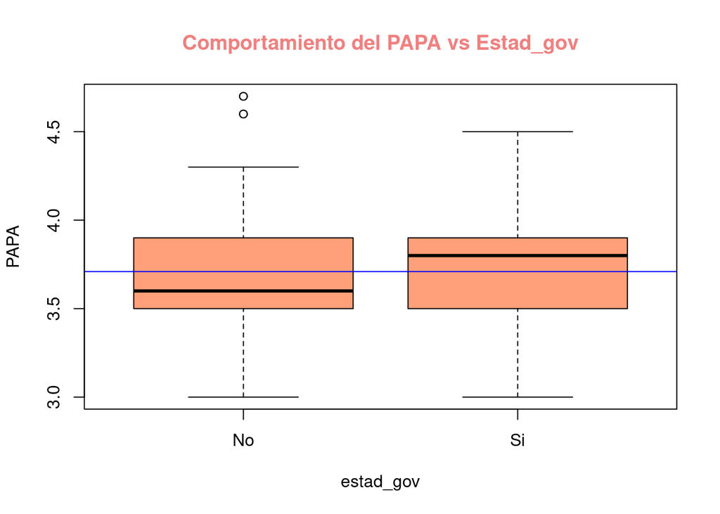

## Analisis estrato

### Analisis descriptivo de la variable Estrato

De esta grafica se puede observar que con un 44.2% la mayoria de los estudiantes matriculados en la materia (EDAED) son estrato 3 (medio), siguiendole el estrato 2 con un 34.3% y ademas de ello, en esta materia no se ecuentra ningun estudiante matriculado de estrato 6.

```
##
##  0  1  2  3  4  5
##  1 17 45 58  9  1
```

```
##
##          0          1          2          3          4          5
##  0.7633588 12.9770992 34.3511450 44.2748092  6.8702290  0.7633588
```

### Gráfica estrato

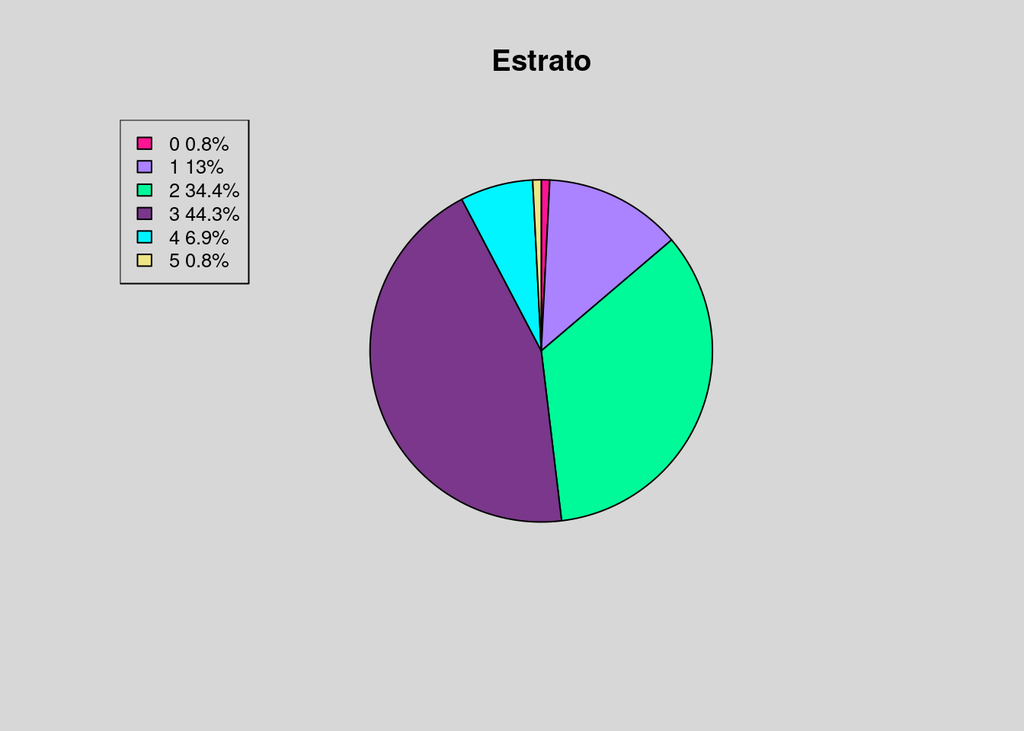

### PAPA vs estrato

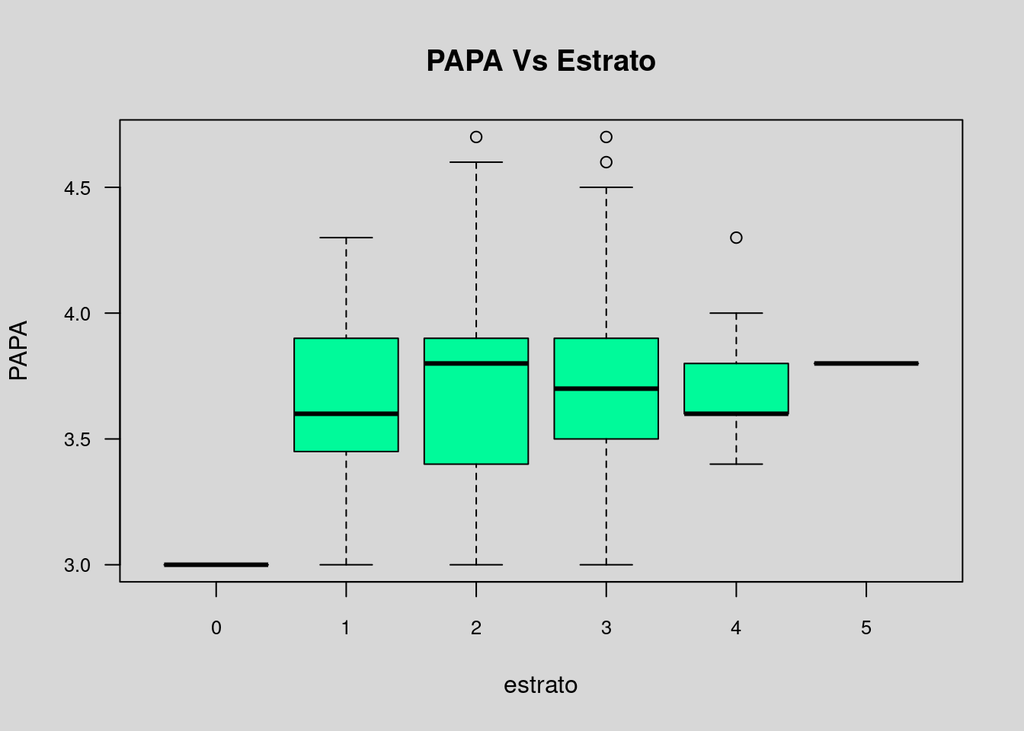

De esta relacion entre las variables Estrato y PAPA, se puede observar que en el estrato 0, se encuentra una persona, la cual tiene un PAPA igual a 3.0. En estrato 1, se encuentran 17 personas que tienen un PAPA promedio entre 3.4 y 3.9, sin embargo la mayor parte de estas personas se acomula entre 3.6 y 3.9. En el estrato 2 se encuentran 45 personas,las cuales tienen un PAPA promedio entre 3.3 y 3.9, sin embargo hay una persona con un PAPA mayor a 4.5 y se sale de este promedio, por esta razon es considerado un dato atipico. En el estrato 3 se concentran la mayor parte de los estudiantes con un PAPA promedio entre 3.5 y 3.9, en este estrato tambien se encuentran datos atipicos con un PAPA superior a 4.5. En el estrato 4 se encuentran 9 personas con un PAPA promedio entre 3.6 y 3.8, encontrando es est tabien un dato atipico con un PAPA promedio superior a 4.0. En el estrato 5 se enceuntra solo una persona con un PAPA promedio igual a 3.8. De esta grafica podemos concluir que siendo el estrato 0 el mas bajo, tiene tambien el promedio PAPA mas bajo, quizas el estrato afecte directamente el PAPA.

## Analisis del computador de mesa

### Analisis exploratorio de ¿Tiene computador de mesa?

De esta grafica se puede evidenciar que mas de la mitad de los estudiantes matriculados es la materia (EDAED) NO tienen computador de mesa.

```
##
## No Si
## 91 41
```

```
##
##       No       Si
## 68.93939 31.06061
```

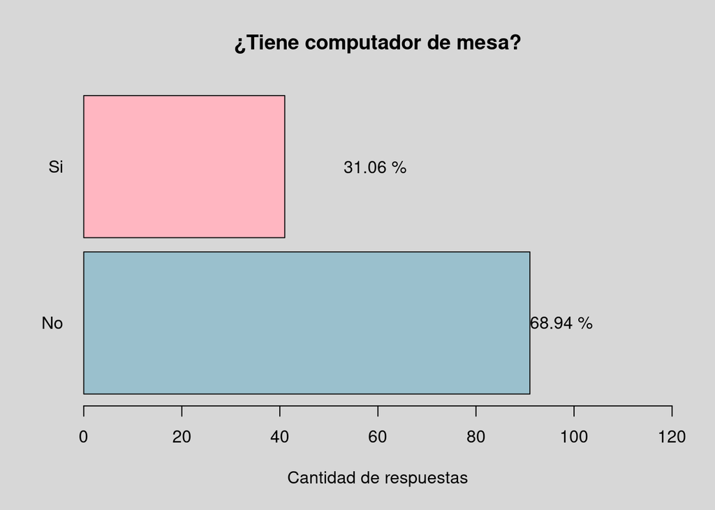

### Grafica PAPA vs computador de mesa

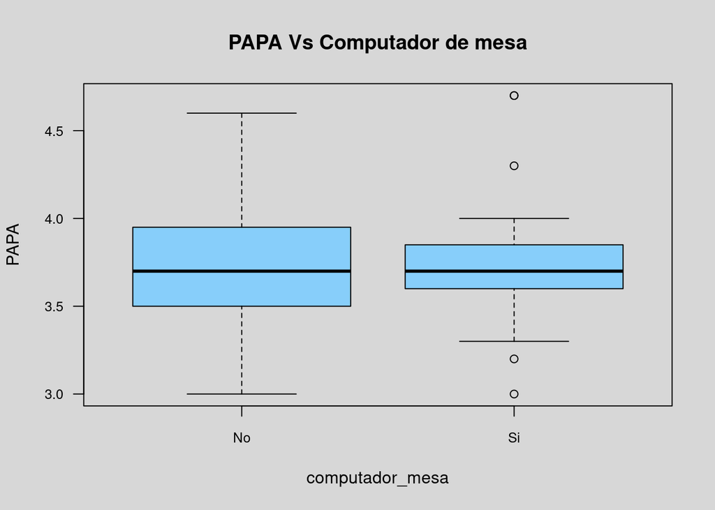

De esta relacion entre las variables PAPA y si tiene o no computador de mesa, se puede evidenciar que no afecta el PAPA, ya que ambas se encuentran en un mismo promedio.

## Análisis computador portatil

### Análisis exploratorio ¿Tiene computador portatil?

De esta grafica se puede evidenciar con un 86.4% que hay una gran cantidad de estudiantes que tienen computador portatil,siendo este el mas popular en los ultimos años por su facilidad y comodidad para llevarlo a todas partes.

```
##    Frecuecnia Porcentaje
## Si        114       86.4
## No         18       13.6
```

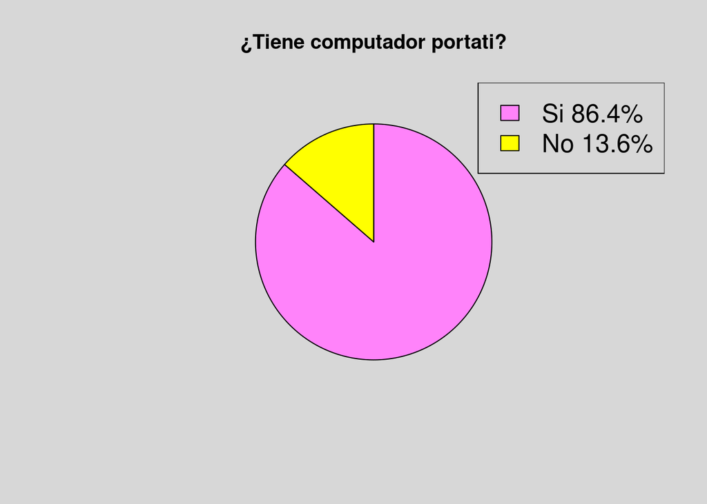

### PAPA vs computador portatil

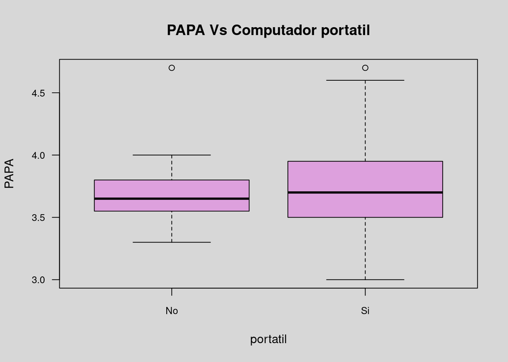

De esta relacion entre las variables PAPA y si tiene o no computador portatil se puede evidenciar que no afecta la una a la otra, ambas se cuentran entre un rango del mismo promedio y ambas tienen datos atipicos.

## Analisis de quien es el portatil

### Analisis exploratorio ¿De quién es el portátil?

Se hizo una distribución para saber de quién es el portátil, se obtuvieron los siguientes resultados.

La siguiente tabla es la distribución de frecuencias de la pregunta que se realizó.

```
##
##  pero alquilado.   pero prestado.          propio.
##                1               16               97
```

La siguiente tabla es de porcentajes de acuerdo a los resultados obtenidos

```
##
##  pero alquilado.   pero prestado.          propio.
##         0.877193        14.035088        85.087719
```

### Diagrama de barras ¿De quién es el portátil?

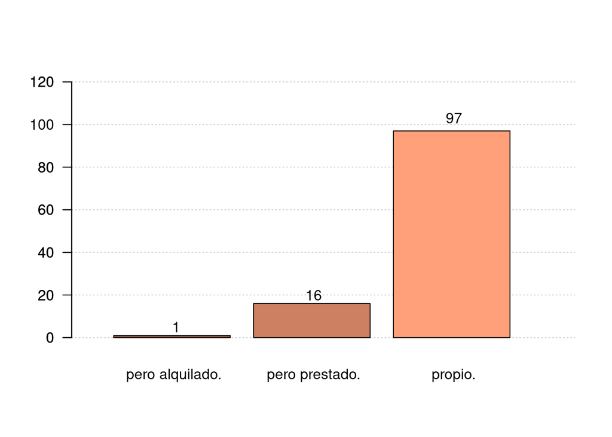

- La mayoria de personas encuestadas (97) tienen un portátil propio.

- Solamente 16 personas de 132 encuestados les prestaron un portátil.
- Una persona alquiló un computador portátil.

### Diagrama de caja PAPA vs ¿De quién es el portátil?

Cuando se hace el analisis entre estas variables obtenemos estos resultados:

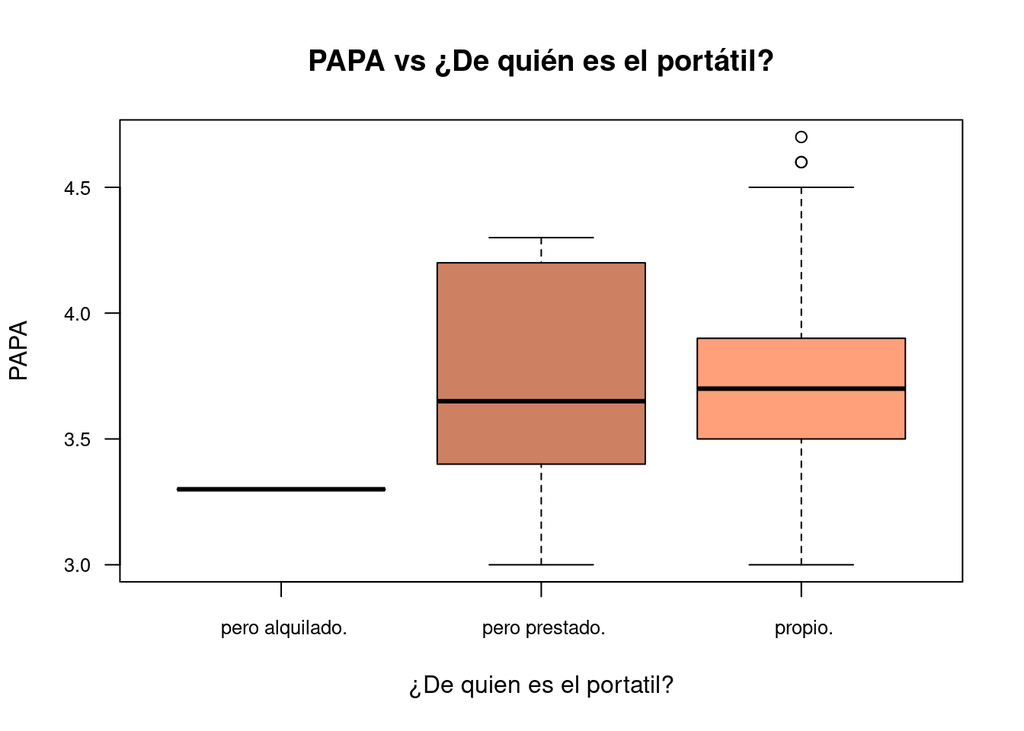

[output not shown]

[output not shown]

## Análisis de la variable internet

### Analisis exploratorio de la variable internet

```
##
##  Si
## 132
```

```
##
##  Si
## 100
```

El 100% de la personas encuestadas tienen internet.

### Diagrama de caja PAPA vs Internet

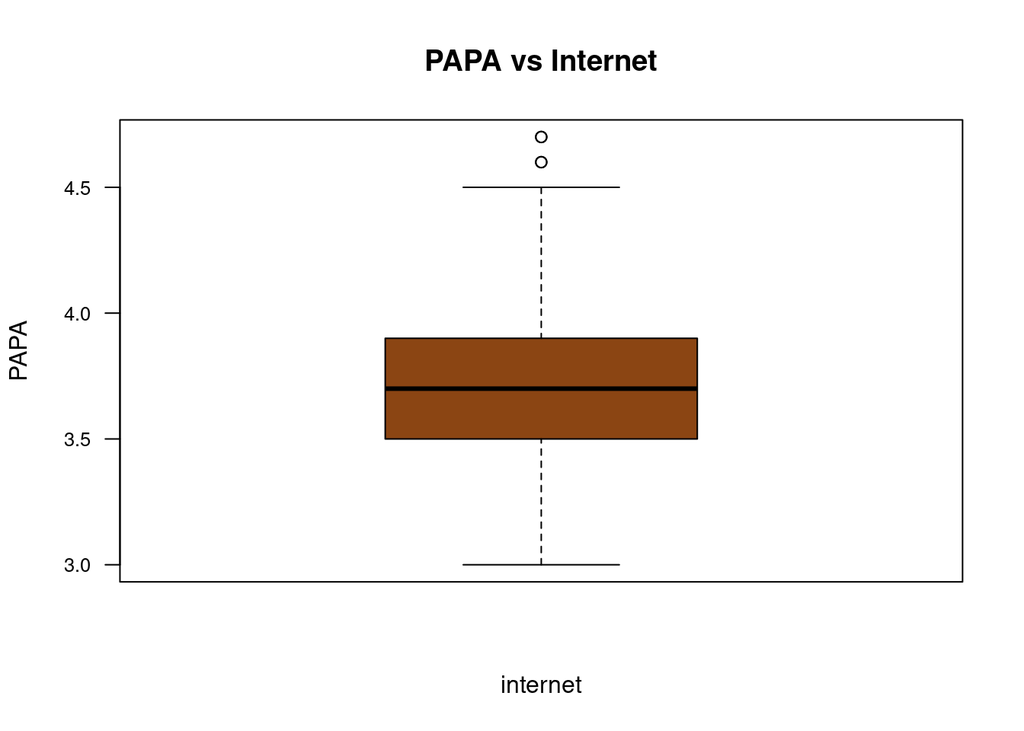

```
##
##                      alquilado               de "contrabando"
##                              6                              1
##                       familiar  pero plan de datos de celular
##                             72                              4
##                       prestado                         propio
##                              5                             44
```

```
##
##                      alquilado               de "contrabando"
##                      4.5454545                      0.7575758
##                       familiar  pero plan de datos de celular
##                     54.5454545                      3.0303030
##                       prestado                         propio
##                      3.7878788                     33.3333333
```

### Diagrama de barras ¿De quién es el internet?

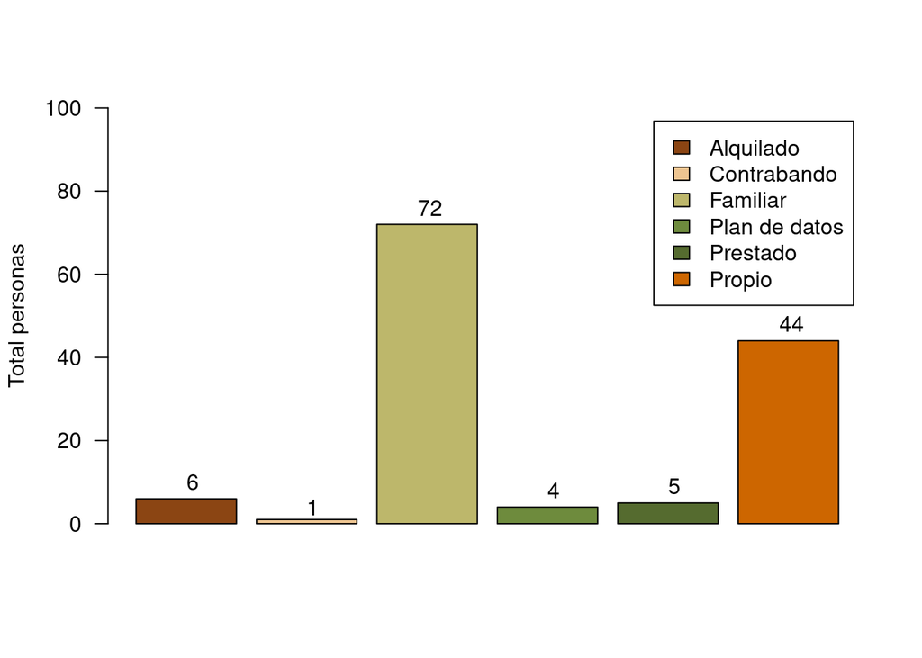

- La mayor cantidad de personas encuestadas poseen internet familiar, seguido en cantidad por internet propio.
- Solo una persona de las que fueron encuestadas posee internet de contrabando.

### Diagrama de bigotes PAPA vs ¿De quién es el internet?

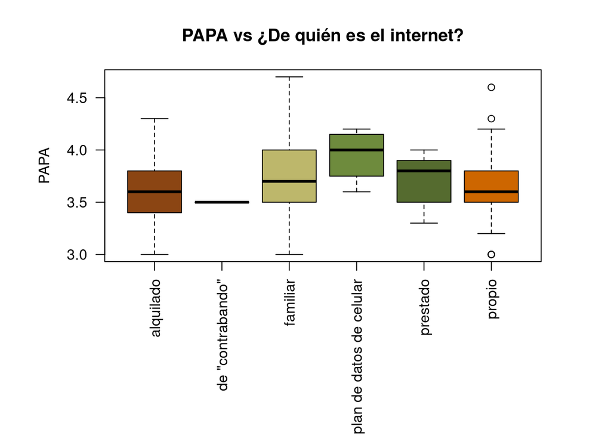

# Variables mas relevantes

En el siguiente grafico anlizamos las variables mas relevantes con el PAPA y podemos observar que los que establecen un horario de estudio y lo cumplen tienen mejores resultados que el resto, eso se puede ver ya que nadie del segundo cuartil tiene resultados malos y de hecho las personas que estan en este cuartil ya estan muy cerca de la mediana de las personas que respondieron la encuesta y los que estan en el tercer cuartil suelen tener aun mejores resultados.

En la grafica podemos observar que en el estrato 3 hay dos datos atipicos con respecto a las otras variables que solo tienen una o ninguna.

Del diagrama se ve que las personas que estan en el estrato 2 que estan en el segundo quartil empiezan con resultados peores que el resto, pero del tercer quartil en adelante tienen muy buenos resultados y todos se agrupan en notas muy cercanas.

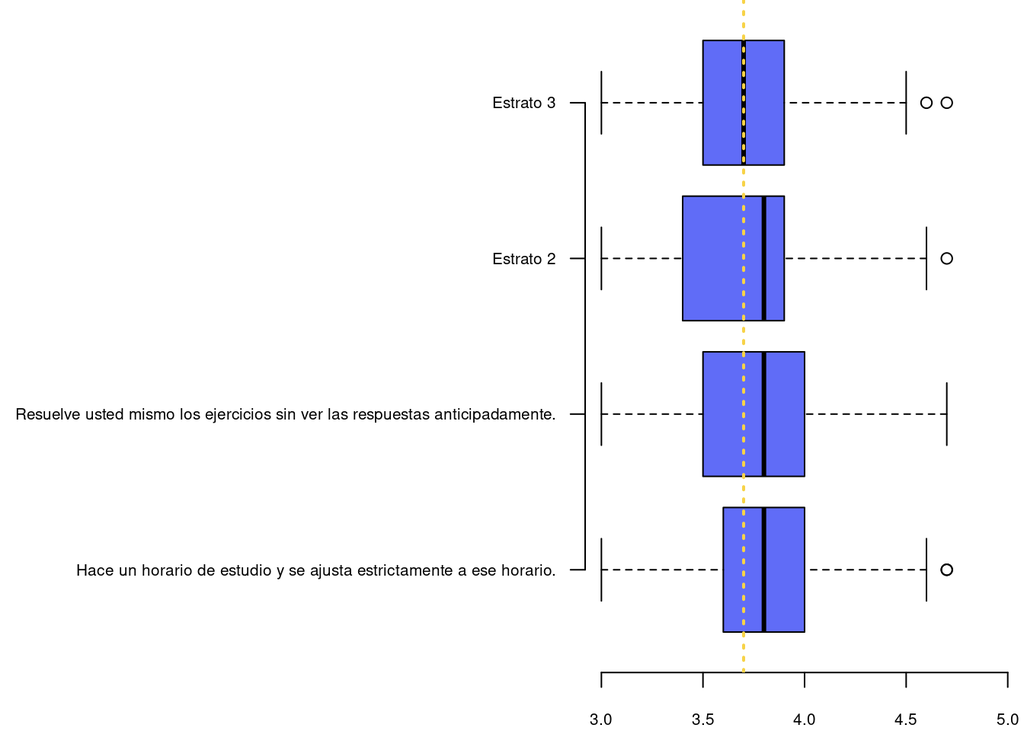

# Recomendaciones

Hubiera sido mas fácil preguntar a los encuestados por la edad y no preguntarles la fecha de nacimiento, ya que así la gente hubiera cometido menos errores a la hora de digitar este dato.

Sería conveniente que se estableciera una edad miníma para evitar que las personas pongan fechas de nacimiento que no eran posibles.

En varias preguntas como si tienen internet o computador hubiera sido conveniente preguntar primero si se tiene internet y en otra pregunta aparte preguntar de quien es el internet, para tener mejor clasificada la variable.

# Conclusiones

Aunque se crea que hay variables que a primera vista no tienen relación, cuando se hace el analisis exploratorio, se puede encontrar una relación que estaba oculta.

Se debe tener cuidado al sacar conclusiones con pocos datos ya que estas pueden intodudcir un sesgo, asi mismo pasa con los datos erroneos estos tambien llevan a conclusiones erradas.

Ya que los datos no siempre llegan de una manera práctica para hacer un análisis primero hay que hacer una verificación y limpieza para realizar el análisis.